# EasyVisa Project

### **Random Forest Classifier**

```python
#Random Forest Classifier with no specific parameter
rf_estimator = RandomForestClassifier(random_state=1)
rf_estimator.fit(X_train, y_train)
```

```
RandomForestClassifier(random_state=1)
```

```python
model_performance_classification_sklearn(rf_estimator, X_train, y_train)
```

|  | Accuracy | Recall | Precision | F1 |
| --- | --- | --- | --- | --- |
| 0 | 0.999944 | 1.0 | 0.999916 | 0.999958 |

```python
model_performance_classification_sklearn(rf_estimator, X_test, y_test)
```

|  | Accuracy | Recall | Precision | F1 |
| --- | --- | --- | --- | --- |
| 0 | 0.71683 | 0.819839 | 0.770876 | 0.794604 |

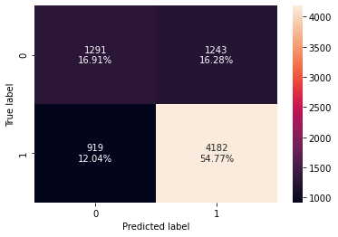

```python
confusion_matrix_sklearn(rf_estimator, X_test, y_test)
```

**Observations**

- Model is overfitting
- confusion mattrix is acceptable

```python
rf_estimator_model_train_perf = model_performance_classification_sklearn(rf_estimator, X_train, y_train)
```

```python
rf_estimator_model_test_perf = model_performance_classification_sklearn(rf_estimator, X_test, y_test)
```

### **Random Forest Tuned**

```python
# Choose the type of classifier.
rf_tuned = RandomForestClassifier(class_weight= {0:0.67,1:0.33}, random_state=1)

# Grid of parameters to choose from
parameters = {"n_estimators": [10,20,30,40],
    "min_samples_leaf": np.arange(5, 10),
    "max_features": np.arange(0.2, 0.7, 0.1),
    "max_samples": np.arange(0.3, 0.7, 0.1),
             }

# Run the grid search
grid_obj = GridSearchCV(rf_tuned, parameters, scoring='precision',cv=5)
grid_obj = grid_obj.fit(X_train, y_train)

# Set the clf to the best combination of parameters
rf_tuned = grid_obj.best_estimator_

# Fit the best algorithm to the data.
rf_tuned.fit(X_train, y_train)
```

```
RandomForestClassifier(class_weight={0: 0.67, 1: 0.33}, max_features=0.2,
                       max_samples=0.6000000000000001, min_samples_leaf=9,
                       n_estimators=40, random_state=1)
```

```python
model_performance_classification_sklearn(rf_tuned, X_train, y_train)
```

|  | Accuracy | Recall | Precision | F1 |
| --- | --- | --- | --- | --- |
| 0 | 0.751404 | 0.77479 | 0.840627 | 0.806367 |

```python
model_performance_classification_sklearn(rf_tuned, X_test, y_test)
```

|  | Accuracy | Recall | Precision | F1 |
| --- | --- | --- | --- | --- |
| 0 | 0.723903 | 0.750441 | 0.820931 | 0.784105 |

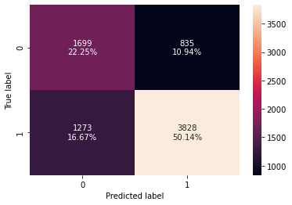

```python
confusion_matrix_sklearn(rf_tuned, X_test, y_test)
```

**Observations**

- Model is fair in terms of performances
- confusion mattrix is acceptable

```python
rf_tuned_model_train_perf = model_performance_classification_sklearn(rf_tuned, X_train, y_train)
```

```python
rf_tuned_model_test_perf = model_performance_classification_sklearn(rf_tuned, X_test, y_test)
```

### **Adaboost Classifier**

```python
#adaboost classifier with no specific parameters
adaboost = AdaBoostClassifier(random_state=1)
adaboost.fit(X_train, y_train)
```

```
AdaBoostClassifier(random_state=1)
```

```python
model_performance_classification_sklearn(adaboost, X_train, y_train)
```

|  | Accuracy | Recall | Precision | F1 |
| --- | --- | --- | --- | --- |
| 0 | 0.738659 | 0.888403 | 0.76063 | 0.819567 |

```python
model_performance_classification_sklearn(adaboost, X_test, y_test)
```

|  | Accuracy | Recall | Precision | F1 |
| --- | --- | --- | --- | --- |
| 0 | 0.734512 | 0.877475 | 0.761483 | 0.815375 |

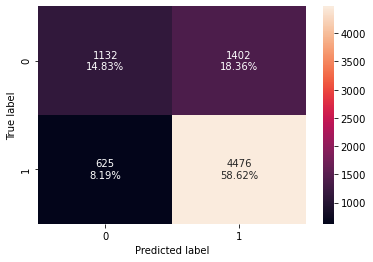

```python
confusion_matrix_sklearn(adaboost, X_test, y_test)
```

**Observations**

- Model performance are good, all the parameters between train and test set are close
- confusion mattrix is improving with 58.6% of true positives, which is our goal

```python
adaboost_model_train_perf = model_performance_classification_sklearn(adaboost, X_train, y_train)
```

```python
adaboost_model_test_perf = model_performance_classification_sklearn(adaboost, X_test, y_test)
```

### **Adaboost Tuned**

```python
adaboost_tuned = AdaBoostClassifier(random_state=1)

# Choose the type of classifier.
adaboost_tuned = AdaBoostClassifier(random_state=1)

# Grid of parameters to choose from
parameters = {
    #Let's try different max_depth for base_estimator
    "base_estimator":[DecisionTreeClassifier(max_depth=1), DecisionTreeClassifier(max_depth=2)],
    "n_estimators": np.arange(10,50,10),
    "learning_rate":np.arange(0.1,2,0.1),
    }

# Type of scoring used to compare parameter  combinations
#scorer = metrics.make_scorer(metrics.f1_score)

# Run the grid search
grid_obj = GridSearchCV(adaboost_tuned, parameters, scoring='precision', cv=5)
grid_obj = grid_obj.fit(X_train, y_train)

# Set the clf to the best combination of parameters
adaboost_tuned = grid_obj.best_estimator_

# Fit the best algorithm to the data.
adaboost_tuned.fit(X_train, y_train)
```

```
AdaBoostClassifier(base_estimator=DecisionTreeClassifier(max_depth=2),
                   learning_rate=1.9000000000000001, n_estimators=10,
                   random_state=1)
```

```python
model_performance_classification_sklearn(adaboost_tuned, X_train, y_train)
```

|  | Accuracy | Recall | Precision | F1 |
| --- | --- | --- | --- | --- |
| 0 | 0.712946 | 0.849916 | 0.752474 | 0.798232 |

```python
model_performance_classification_sklearn(rf_tuned, X_test, y_test)
```

[output not shown]

[figure not shown]

```python
confusion_matrix_sklearn(rf_tuned, X_test, y_test)
```

**Observations**

- model performances downgrades from the non tuned one, which is unusall
- confusion matrix downgrades from the non tuned one

```python
adaboost_tuned_model_train_perf = model_performance_classification_sklearn(adaboost_tuned, X_train, y_train)
```

```python
adaboost_tuned_model_test_perf = model_performance_classification_sklearn(adaboost_tuned, X_test, y_test)
```

### **Gradient Boost Classifier**

```python
gbc = GradientBoostingClassifier(random_state=1)
gbc.fit(X_train, y_train)
```

```
GradientBoostingClassifier(random_state=1)
```

```python
model_performance_classification_sklearn(gbc, X_train, y_train)
```

|  | Accuracy | Recall | Precision | F1 |
| --- | --- | --- | --- | --- |
| 0 | 0.755951 | 0.878487 | 0.782778 | 0.827876 |

```python
model_performance_classification_sklearn(gbc, X_test, y_test)
```

|  | Accuracy | Recall | Precision | F1 |
| --- | --- | --- | --- | --- |
| 0 | 0.747086 | 0.865517 | 0.780035 | 0.820556 |

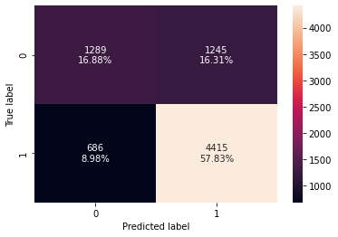

```python
confusion_matrix_sklearn(gbc, X_test, y_test)
```

**Observations**

- good performances of the model
- confusion mattrix is improving except from adaboost untuned

```python
gbc_model_train_perf = model_performance_classification_sklearn(gbc, X_train, y_train)
```

```python
gbc_model_test_perf = model_performance_classification_sklearn(gbc, X_test, y_test)
```

### **Gradient Boost Tuned**

```python
# Choose the type of classifier.
gbc_tuned = GradientBoostingClassifier(init=AdaBoostClassifier(random_state=1),random_state=1)

# Grid of parameters to choose from
parameters = {
    "n_estimators": [100,150,200,250],
    "subsample":[0.8,0.9,1],
    "max_features":[0.7,0.8,0.9,1]
}
# Run the grid search
grid_obj = GridSearchCV(gbc_tuned, parameters, scoring='precision',cv=5)
grid_obj = grid_obj.fit(X_train, y_train)

# Set the clf to the best combination of parameters
gbc_tuned = grid_obj.best_estimator_

# Fit the best algorithm to the data.
gbc_tuned.fit(X_train, y_train)
```

```
GradientBoostingClassifier(init=AdaBoostClassifier(random_state=1),
                           max_features=0.8, n_estimators=150, random_state=1,
                           subsample=0.8)
```

```python
model_performance_classification_sklearn(gbc_tuned, X_train, y_train)
```

|  | Accuracy | Recall | Precision | F1 |
| --- | --- | --- | --- | --- |
| 0 | 0.759376 | 0.876891 | 0.787191 | 0.829623 |

```python
model_performance_classification_sklearn(gbc_tuned, X_test, y_test)
```

|  | Accuracy | Recall | Precision | F1 |
| --- | --- | --- | --- | --- |
| 0 | 0.745907 | 0.864536 | 0.77929 | 0.819703 |

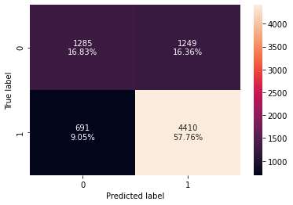

```python
confusion_matrix_sklearn(gbc_tuned, X_test, y_test)
```

**Observations**

- the tuned version give no added value. Performances are good and confusion mattrix stable vs the non tuned Gradient Boost version

```python
gbc_tuned_model_train_perf = model_performance_classification_sklearn(gbc, X_train, y_train)
```

```python
gbc_tuned_model_test_perf = model_performance_classification_sklearn(gbc, X_test, y_test)
```

### **XGB Classifier**

```python
xgb = XGBClassifier(random_state=1, eval_metrics='logloss')
xgb.fit(X_train, y_train)
```

[output not shown]

```
XGBClassifier(base_score=0.5, booster='gbtree', colsample_bylevel=1,
              colsample_bynode=1, colsample_bytree=1, enable_categorical=False,
              eval_metrics='logloss', gamma=0, gpu_id=-1, importance_type=None,
              interaction_constraints='', learning_rate=0.300000012,
              max_delta_step=0, max_depth=6, min_child_weight=1, missing=nan,
              monotone_constraints='()', n_estimators=100, n_jobs=16,
              num_parallel_tree=1, predictor='auto', random_state=1,
              reg_alpha=0, reg_lambda=1, scale_pos_weight=1, subsample=1,
              tree_method='exact', validate_parameters=1, verbosity=None)
```

```python
model_performance_classification_sklearn(xgb, X_train, y_train)
```

|  | Accuracy | Recall | Precision | F1 |
| --- | --- | --- | --- | --- |
| 0 | 0.819841 | 0.922269 | 0.82774 | 0.872451 |

```python
model_performance_classification_sklearn(xgb, X_test, y_test)
```

|  | Accuracy | Recall | Precision | F1 |
| --- | --- | --- | --- | --- |
| 0 | 0.737394 | 0.861204 | 0.772056 | 0.814197 |

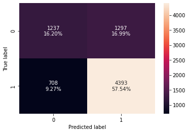

```python
confusion_matrix_sklearn(xgb, X_test, y_test)
```

**Observations**

- slight differences between trained and tested data which may raise some questions about a possible overfit or not.
- confusion mattrix is in the range of the latest boosting models

```python
xgb_model_train_perf = model_performance_classification_sklearn(xgb, X_train, y_train)
```

```python
xgb_model_test_perf = model_performance_classification_sklearn(xgb, X_test, y_test)
```

### **XGBoost Classifier Tuned**

```python
# Choose the type of classifier.
xgb_tuned = XGBClassifier(random_state=1, eval_metric='logloss')

# Grid of parameters to choose from
parameters = {
    "n_estimators": [50,100,150],
    "scale_pos_weight":[33],
    "subsample":[0.7,0.9,1],
    "learning_rate":[0.05, 0.1,0.2],
    "colsample_bytree":[0.7,0.9,1],
    "colsample_bylevel":[0.5,0.7,1]
}

# Run the grid search
grid_obj = GridSearchCV(xgb_tuned, parameters,scoring='precision',cv=5)
grid_obj = grid_obj.fit(X_train, y_train)

# Set the clf to the best combination of parameters
xgb_tuned = grid_obj.best_estimator_

# Fit the best algorithm to the data.
xgb_tuned.fit(X_train, y_train)
```

```
XGBClassifier(base_score=0.5, booster='gbtree', colsample_bylevel=0.7,
              colsample_bynode=1, colsample_bytree=1, enable_categorical=False,
              eval_metric='logloss', gamma=0, gpu_id=-1, importance_type=None,
              interaction_constraints='', learning_rate=0.2, max_delta_step=0,
              max_depth=6, min_child_weight=1, missing=nan,
              monotone_constraints='()', n_estimators=150, n_jobs=16,
              num_parallel_tree=1, predictor='auto', random_state=1,
              reg_alpha=0, reg_lambda=1, scale_pos_weight=33, subsample=0.7,
              tree_method='exact', validate_parameters=1, verbosity=None)
```

```python
model_performance_classification_sklearn(xgb_tuned, X_train, y_train)
```

|  | Accuracy | Recall | Precision | F1 |
| --- | --- | --- | --- | --- |
| 0 | 0.704693 | 1.0 | 0.693473 | 0.818995 |

```python
model_performance_classification_sklearn(xgb_tuned, X_test, y_test)
```

|  | Accuracy | Recall | Precision | F1 |
| --- | --- | --- | --- | --- |
| 0 | 0.685134 | 0.992158 | 0.681616 | 0.808079 |

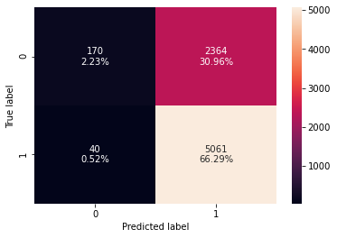

```python
confusion_matrix_sklearn(xgb_tuned, X_test, y_test)
```

**Observation**

- model performances are close between trained and tested dataset. However, precision decline which raise questions about the added value of this model.
- confusion matrix downgrade with a strong increase of false positives

```python
xgb_tuned_model_train_perf = model_performance_classification_sklearn(xgb_tuned, X_train, y_train)
```

```python
xgb_tuned_model_test_perf = model_performance_classification_sklearn(xgb_tuned, X_test, y_test)
```

### **Stacking Classifier**

```python
estimators = [('Random Forest',rf_estimator), ('Gradient Boosting',gbc_tuned), ('Decision Tree',dtree_tuned)]

final_estimator = xgb_tuned

stacking_classifier= StackingClassifier(estimators=estimators,final_estimator=final_estimator)

stacking_classifier.fit(X_train,y_train)
```

```
StackingClassifier(estimators=[('Random Forest',
                                RandomForestClassifier(random_state=1)),
                               ('Gradient Boosting',
                                GradientBoostingClassifier(init=AdaBoostClassifier(random_state=1),
                                                           max_features=0.8,
                                                           n_estimators=150,
                                                           random_state=1,
                                                           subsample=0.8)),
                               ('Decision Tree',
                                DecisionTreeClassifier(class_weight={0: 0.67,
                                                                     1: 0.33},
                                                       max_depth=4,
                                                       max_leaf_nodes=10,
                                                       min_impurity_...
                                                 gpu_id=-1,
                                                 importance_type=None,
                                                 interaction_constraints='',
                                                 learning_rate=0.2,
                                                 max_delta_step=0, max_depth=6,
                                                 min_child_weight=1,
                                                 missing=nan,
                                                 monotone_constraints='()',
                                                 n_estimators=150, n_jobs=16,
                                                 num_parallel_tree=1,
                                                 predictor='auto',
                                                 random_state=1, reg_alpha=0,
                                                 reg_lambda=1,
                                                 scale_pos_weight=33,
                                                 subsample=0.7,
                                                 tree_method='exact',
                                                 validate_parameters=1,
                                                 verbosity=None))
```

```python
model_performance_classification_sklearn(stacking_classifier, X_train, y_train)
```

|  | Accuracy | Recall | Precision | F1 |
| --- | --- | --- | --- | --- |
| 0 | 0.687851 | 0.975462 | 0.687841 | 0.806783 |

```python
model_performance_classification_sklearn(stacking_classifier, X_test, y_test)
```

|  | Accuracy | Recall | Precision | F1 |
| --- | --- | --- | --- | --- |
| 0 | 0.686182 | 0.988238 | 0.68334 | 0.807982 |

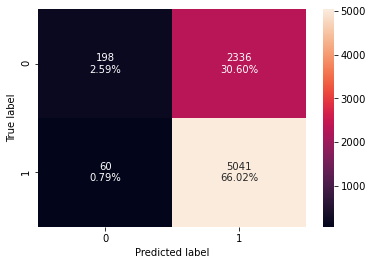

```python
confusion_matrix_sklearn(stacking_classifier, X_test, y_test)
```

**Observations**

- model performances are comparable with XGBoost ones, parameters are close between trained and tested dataset so there is no overfitting. However, precision declines vs others models.
- confusion matrix is unsatisfactory with a high level of false positives vs other models (except XGBoost which share the same problem)

```python
stacking_classifier_model_train_perf = model_performance_classification_sklearn(stacking_classifier, X_train, y_train)
```

```python
stacking_classifier_model_test_perf = model_performance_classification_sklearn(stacking_classifier, X_test, y_test)
```

```python
# training performance comparison

models_train_comp_df = pd.concat(
    [dtree_model_train_perf.T,
     dtree_tuned_model_train_perf.T,
     rf_estimator_model_train_perf.T,
     rf_tuned_model_train_perf.T,
     bagging_estimator_model_train_perf.T,
     bagging_estimator_tuned_model_train_perf.T,
     adaboost_model_train_perf.T,
     adaboost_tuned_model_train_perf.T,
     gbc_model_train_perf.T,
     gbc_tuned_model_train_perf.T,
     xgb_model_train_perf.T,
    xgb_tuned_model_train_perf.T,
    stacking_classifier_model_train_perf.T],
    axis=1,
)

models_train_comp_df.columns = [
    "Decision Tree",
    "Decision Tree tuned",
    "Random Classifier",
    "Random Classifier Tuned",
    "Bagging Classifier",
    "Bagging Estimator Tuned",
    "Adaboost Classifier",
    "Adabosst Classifier Tuned",
    "Gradient Boost Classifier",
    "Gradient Boost Classifier Tuned",
    "XGBoost Classifier",
    "XGBoost Classifier Tuned",
    "Stacking Classifier"]
print("Training performance comparison:")
#models_train_comp_df
```

```
Training performance comparison:
```

```python
# training performance comparison

models_test_comp_df = pd.concat(
    [dtree_model_test_perf.T,
     dtree_tuned_model_test_perf.T,
     rf_estimator_model_test_perf.T,
     rf_tuned_model_test_perf.T,
     bagging_estimator_model_test_perf.T,
     bagging_estimator_tuned_model_test_perf.T,
     adaboost_model_test_perf.T,
     adaboost_tuned_model_test_perf.T,
     gbc_model_test_perf.T,
     gbc_tuned_model_test_perf.T,
     xgb_model_test_perf.T,
    xgb_tuned_model_test_perf.T,
    stacking_classifier_model_test_perf.T],
    axis=1,
)

models_test_comp_df.columns = [
    "Decision Tree",
    "Decision Tree tuned",
    "Random Classifier",
    "Random Classifier Tuned",
    "Bagging Classifier",
    "Bagging Estimator Tuned",
    "Adaboost Classifier",
    "Adabosst Classifier Tuned",
    "Gradient Boost Classifier",
    "Gradient Boost Classifier Tuned",
    "XGBoost Classifier",
    "XGBoost Classifier Tuned",
    "Stacking Classifier"]
print("Training performance comparison:")
models_test_comp_df
```

```
Training performance comparison:
```

|  | Decision Tree | Decision Tree tuned | Random Classifier | Random Classifier Tuned | Bagging Classifier | Bagging Estimator Tuned | Adaboost Classifier | Adabosst Classifier Tuned | Gradient Boost Classifier | Gradient Boost Classifier Tuned | XGBoost Classifier | XGBoost Classifier Tuned | Stacking Classifier |
| --- | --- | --- | --- | --- | --- | --- | --- | --- | --- | --- | --- | --- | --- |
| Accuracy | 0.655403 | 0.705566 | 0.716830 | 0.723903 | 0.699411 | 0.724558 | 0.734512 | 0.708448 | 0.747086 | 0.747086 | 0.737394 | 0.685134 | 0.686182 |
| Recall | 0.745932 | 0.724172 | 0.819839 | 0.750441 | 0.778671 | 0.850618 | 0.877475 | 0.847481 | 0.865517 | 0.865517 | 0.861204 | 0.992158 | 0.988238 |
| Precision | 0.740272 | 0.814553 | 0.770876 | 0.820931 | 0.773063 | 0.763908 | 0.761483 | 0.749090 | 0.780035 | 0.780035 | 0.772056 | 0.681616 | 0.683340 |
| F1 | 0.743091 | 0.766708 | 0.794604 | 0.784105 | 0.775857 | 0.804935 | 0.815375 | 0.795254 | 0.820556 | 0.820556 | 0.814197 | 0.808079 | 0.807982 |

```python
models_train_comp_df
```

|  | Decision Tree | Decision Tree tuned | Random Classifier | Random Classifier Tuned | Bagging Classifier | Bagging Estimator Tuned | Adaboost Classifier | Adabosst Classifier Tuned | Gradient Boost Classifier | Gradient Boost Classifier Tuned | XGBoost Classifier | XGBoost Classifier Tuned | Stacking Classifier |
| --- | --- | --- | --- | --- | --- | --- | --- | --- | --- | --- | --- | --- | --- |
| Accuracy | 1.0 | 0.710925 | 0.999944 | 0.751404 | 0.983101 | 0.986414 | 0.738659 | 0.712946 | 0.755951 | 0.755951 | 0.819841 | 0.704693 | 0.687851 |
| Recall | 1.0 | 0.730840 | 1.000000 | 0.774790 | 0.984622 | 0.995294 | 0.888403 | 0.849916 | 0.878487 | 0.878487 | 0.922269 | 1.000000 | 0.975462 |
| Precision | 1.0 | 0.817157 | 0.999916 | 0.840627 | 0.990030 | 0.984539 | 0.760630 | 0.752474 | 0.782778 | 0.782778 | 0.827740 | 0.693473 | 0.687841 |
| F1 | 1.0 | 0.771592 | 0.999958 | 0.806367 | 0.987318 | 0.989887 | 0.819567 | 0.798232 | 0.827876 | 0.827876 | 0.872451 | 0.818995 | 0.806783 |

**Observations**

- some models overfit : decision tree, Random Classifier, Bagging, Bagging estimator Tuned
- some models give a poor precision levels with a higher level of false positives than the others : XGBoost Classifier Tuned and Stacking Classifier
- some models looks acceptable in terms of non overfitting and precision level : Decision Tree Tuned, Random Classifier Tuned, Adaboost Classifier, Adaboost Classifier Tuned, Gradient Boost Classifier, Gradient Boost Classifier Tuned and XGBoost Classifier.

**we will explore furter these models in terms of importances**

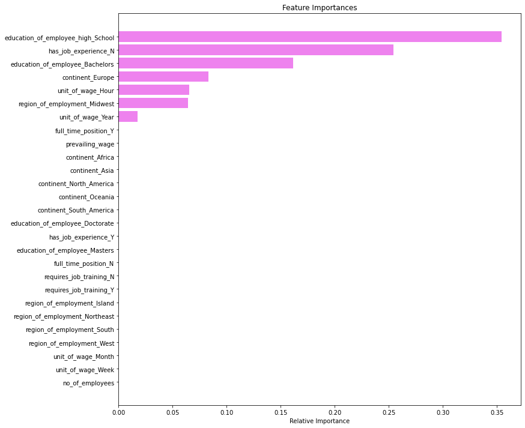

```python
feature_names = X_train.columns
importances = dtree_tuned.feature_importances_
indices = np.argsort(importances)

plt.figure(figsize=(12,12))
plt.title('Feature Importances')
plt.barh(range(len(indices)), importances[indices], color='violet', align='center')
plt.yticks(range(len(indices)), [feature_names[i] for i in indices])
plt.xlabel('Relative Importance')
plt.show()
```

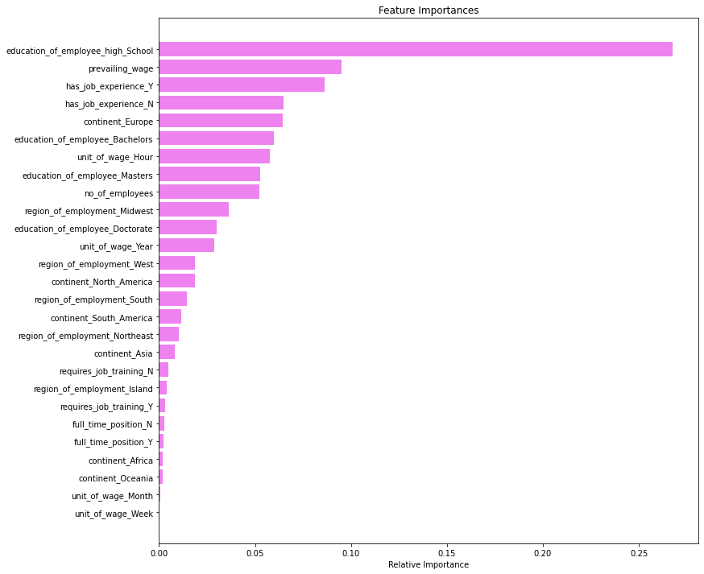

```python
feature_names = X_train.columns
importances = gbc_tuned.feature_importances_
indices = np.argsort(importances)

plt.figure(figsize=(12,12))
plt.title('Feature Importances')
plt.barh(range(len(indices)), importances[indices], color='violet', align='center')
plt.yticks(range(len(indices)), [feature_names[i] for i in indices])
plt.xlabel('Relative Importance')
plt.show()
```

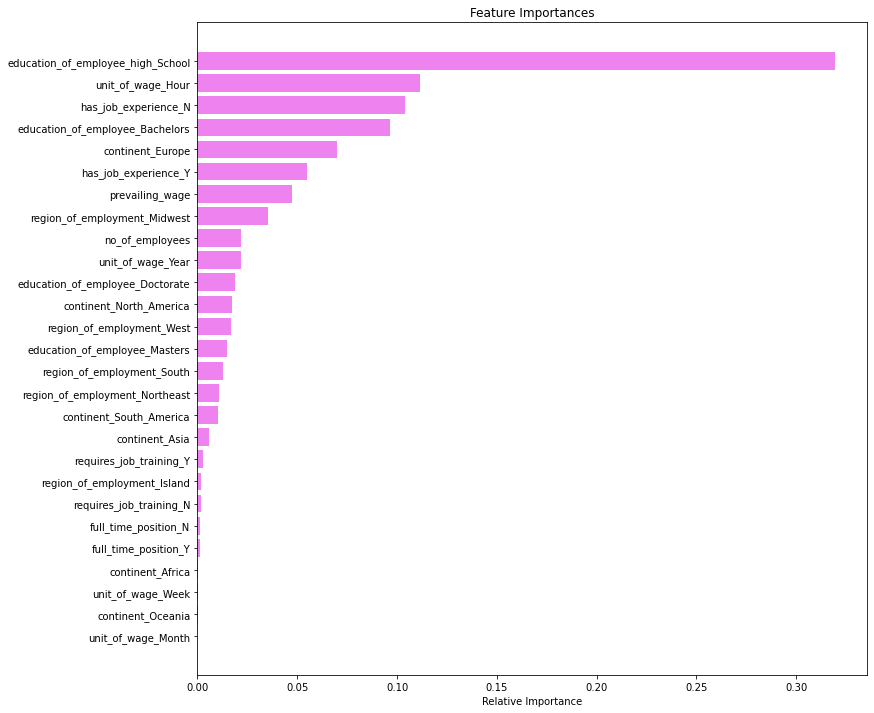

```python
feature_names = X_train.columns
importances = gbc.feature_importances_
indices = np.argsort(importances)

plt.figure(figsize=(12,12))
plt.title('Feature Importances')
plt.barh(range(len(indices)), importances[indices], color='violet', align='center')
plt.yticks(range(len(indices)), [feature_names[i] for i in indices])
plt.xlabel('Relative Importance')
plt.show()
```

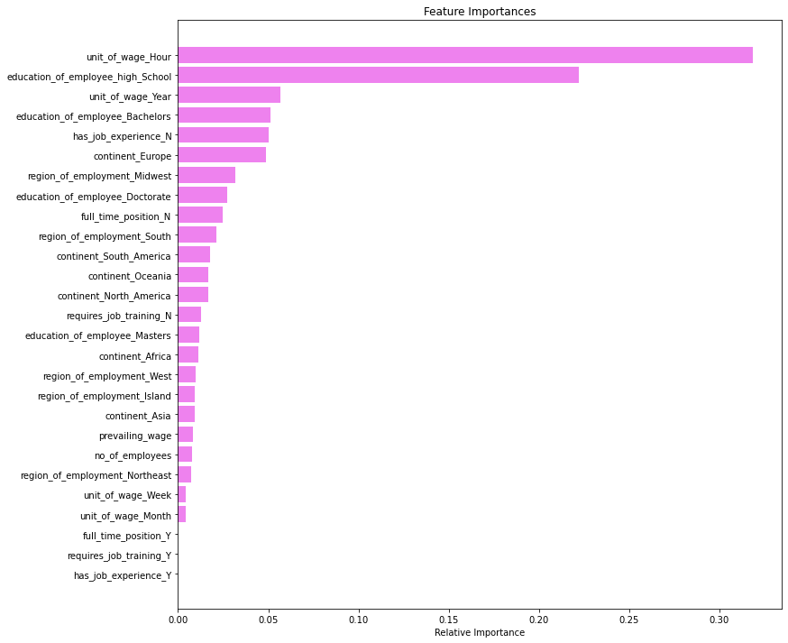

```python
feature_names = X_train.columns
importances = xgb.feature_importances_
indices = np.argsort(importances)

plt.figure(figsize=(12,12))
plt.title('Feature Importances')
plt.barh(range(len(indices)), importances[indices], color='violet', align='center')
plt.yticks(range(len(indices)), [feature_names[i] for i in indices])
plt.xlabel('Relative Importance')
plt.show()
```

**Observations**

- The importances looks to be in majority High School, unit of wage hour and no job experience. This contradict what we found in EDA part where we stands that the higher the education level is the better the certified probability. The same for unit of wage where we demonstrate that year unit of wage gives a better chance to be certified.
- This contradictions raise questions about the Importance relevance. Several elements in the "litterature" supposed that somehow, Importance doesn't work as it should be. Several suggest to use "Permutation Importance" to solve that issue. We explore that possibility and see where this will lead us.

```python
r = permutation_importance(rf_tuned, X_test, y_test,
                            n_repeats=30,
                            random_state=0)
```

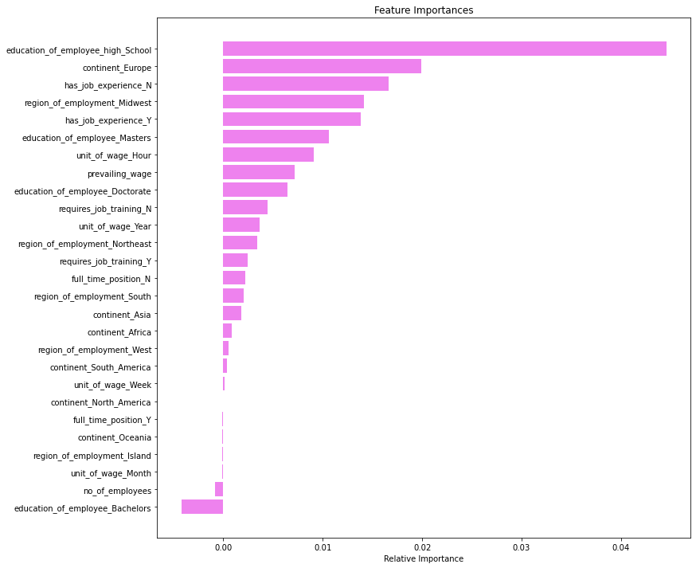

```python
feature_names = X_train.columns
importances = r.importances_mean
indices = np.argsort(importances)

plt.figure(figsize=(12,12))
plt.title('Feature Importances')
plt.barh(range(len(indices)), importances[indices], color='violet', align='center')
plt.yticks(range(len(indices)), [feature_names[i] for i in indices])
plt.xlabel('Relative Importance')
plt.show()
```

```python
r = permutation_importance(dtree_tuned, X_test, y_test,
                            n_repeats=30,
                            random_state=0)
```

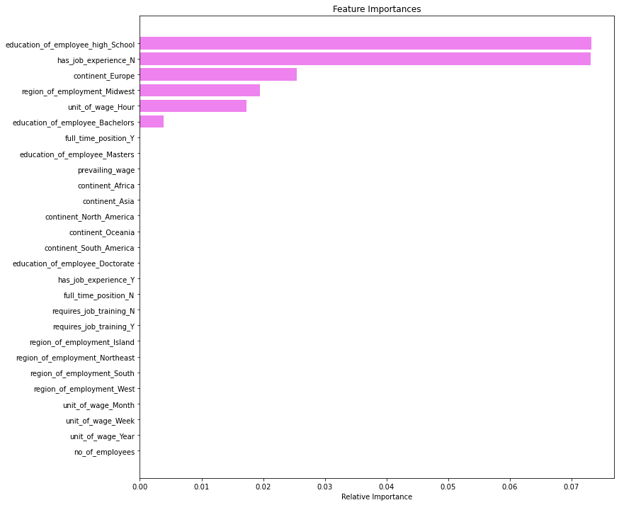

```python
feature_names = X_train.columns
importances = r.importances_mean
indices = np.argsort(importances)

plt.figure(figsize=(12,12))
plt.title('Feature Importances')
plt.barh(range(len(indices)), importances[indices], color='violet', align='center')
plt.yticks(range(len(indices)), [feature_names[i] for i in indices])
plt.xlabel('Relative Importance')
plt.show()
```

```python
r = permutation_importance(gbc_tuned, X_test, y_test,
                            n_repeats=30,
                            random_state=0)
```

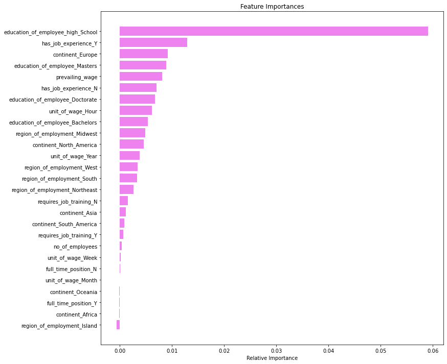

```python
feature_names = X_train.columns
importances = r.importances_mean
indices = np.argsort(importances)

plt.figure(figsize=(12,12))
plt.title('Feature Importances')
plt.barh(range(len(indices)), importances[indices], color='violet', align='center')
plt.yticks(range(len(indices)), [feature_names[i] for i in indices])
plt.xlabel('Relative Importance')
plt.show()
```

```python
r = permutation_importance(xgb, X_test, y_test,
                            n_repeats=30,
                            random_state=0)
```

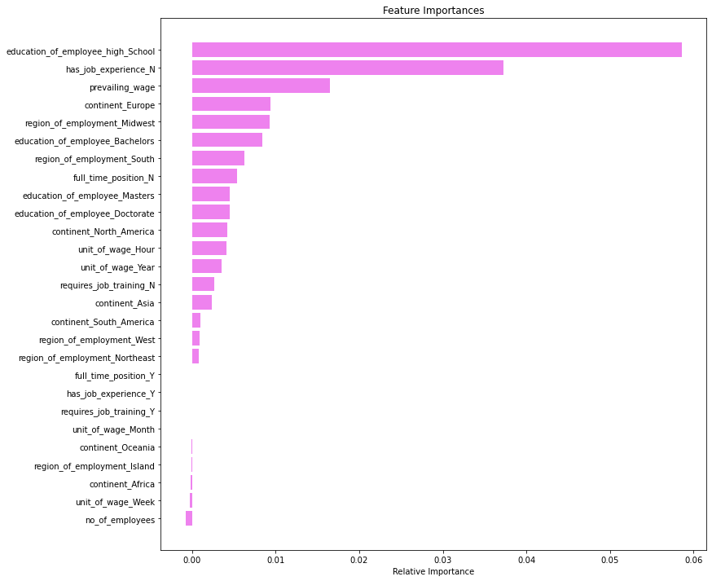

```python
feature_names = X_train.columns
importances = r.importances_mean
indices = np.argsort(importances)

plt.figure(figsize=(12,12))
plt.title('Feature Importances')
plt.barh(range(len(indices)), importances[indices], color='violet', align='center')
plt.yticks(range(len(indices)), [feature_names[i] for i in indices])
plt.xlabel('Relative Importance')
plt.show()
```

```python
r = permutation_importance(gbc, X_test, y_test,
                            n_repeats=30,
                            random_state=0)
```

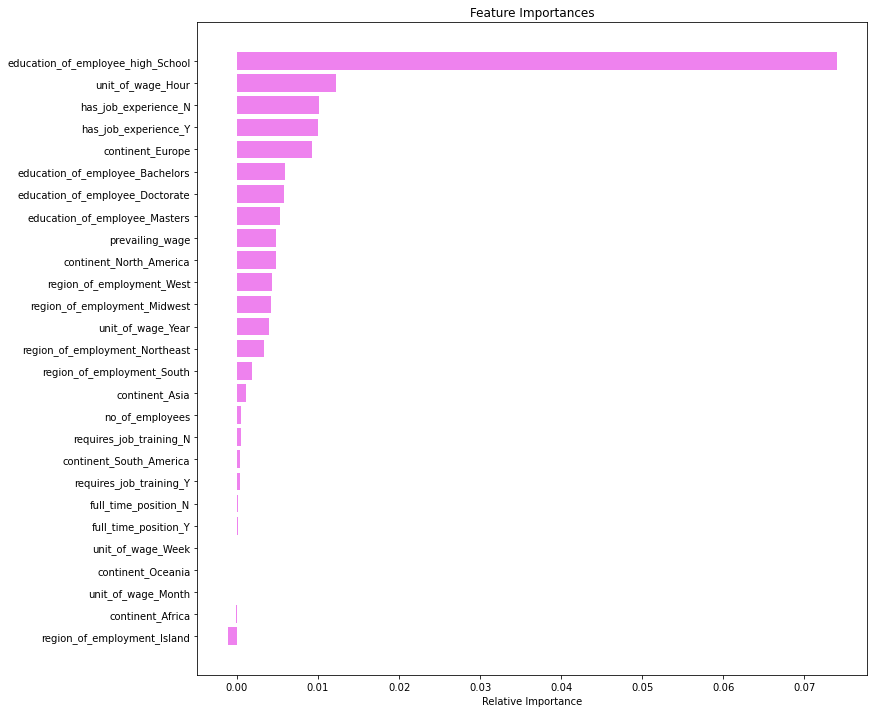

```python
feature_names = X_train.columns
importances = r.importances_mean
indices = np.argsort(importances)

plt.figure(figsize=(12,12))
plt.title('Feature Importances')
plt.barh(range(len(indices)), importances[indices], color='violet', align='center')
plt.yticks(range(len(indices)), [feature_names[i] for i in indices])
plt.xlabel('Relative Importance')
plt.show()
```

**Observations**

- Permutation Importance doesn't solve our problem but it makes others variables more "visible"
- For some reason the models highlighted the lower variables, which raise questions about the parameter we used.

**Conclusions**

From EDA perspectives the best parameters which help to be certified are : 1- education, the higher the better 2- continent origin plays a role in the status case 3- prevailing wage, the higher the better 4- unit of payment, the longer the better 4- having job experience

These elements were statistically determined and are quite consistent with time.

From bagging and boosting models, the conclusions looks different :

```
1- High School grade migrants have a better chance to be certified than the others
2- Not having job experience looks important
3- payment in hour
4- European origin
5- working in the Midwest region
```

The High School education and the job experience looks over-expressed, the difference with the other parameters is too big. Thus we could conclude to a mathematic anomaly (noise, overexpression due to low numbers, algorithm mistreatment...). Beyond these parameters, the other ones, especially with the "Permutated Importance" ones, can be detected. Beyond these parameters that we could consider as "anomaly", the others looks reasonnable regarding EDA.

These parameters are more classical as in the 'Permutated Importance' rf_tuned or gbc tuned. These two let some interesting parameters to express like :

```
- Having job experience
- continent Europe
- education of employee Master's
- prevailing wage
- education of employee Doctorate
```

**We chose to consider these latest elements as conclusive from the model and to step aside education of employee high school grade, unit of wage hour and Not having job experience.**

**Visa Approval Recommandations**

In light of these elements, we recommand to favour candidates in light of the following elements :

- Those who have job experience
- Those who comes from Europe or North America
- Those who have a Masters degree or a Doctorate
- Those who have a higher prevailing wage
- Those who have a year unit of wage
- Those who intend to work in the Midwest, South or Northeast region